# Graficar en R (bias genético)

### Histogramas

Ejemplo con los datos islands (viene con R)

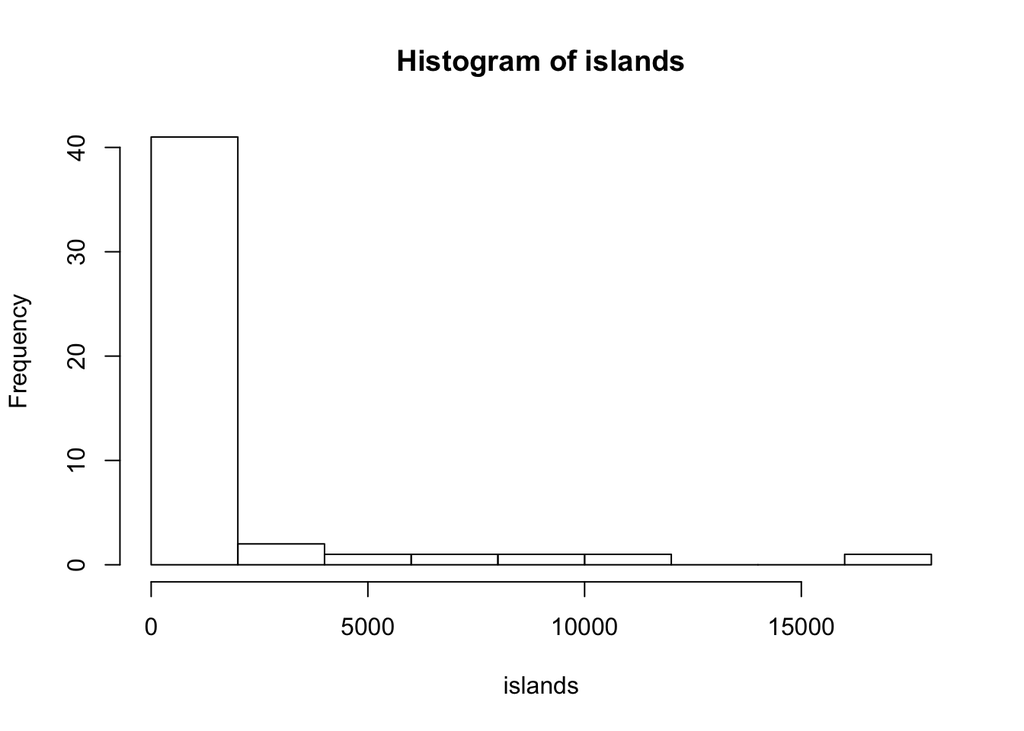

```r
hist(islands)
```

**Ejercicio** En “Practicas/Uni7/data/reads.txt” encontrarás un archivo con la cantidad de lecturas de las muestras de tres librerías que fueron secuenciadas en Illumina. Grafica un histograma de las lecturas de cada muestra.

### Barplot

Ejemplo:

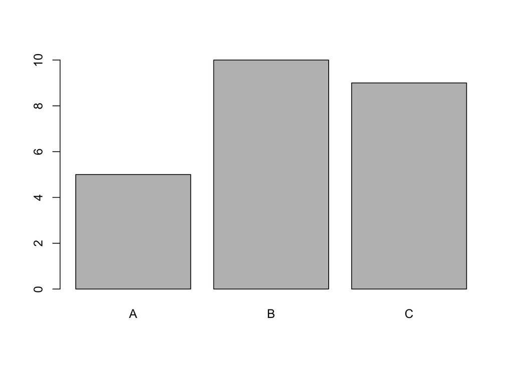

```r
DNAcon<-data.frame(muestra=c("A", "B", "C"), concentracionADN=c(5,10,9))
barplot(DNAcon$concentracionADN, names.arg=DNAcon$muestra)
```

**Ejercicio** Repite la gráfica de DNAcon pero agregando títulos a los ejes x,y

Ahora cargemos un archivo real de datos:

```r
reads<-read.delim("../Practicas/Uni7/data/reads.txt")
```

Hagamos una gráfica de barras y colorear acorde a info contenida en otra columna:

```r
head(reads)
```

```
##   Library    sample  nreads
## 1    Lib1  pobA21_r 1381230
## 2    Lib1    pobB10 1726622
## 3    Lib1    pobB05  819766
## 4    Lib1    pobC05  442508
## 5    Lib1  pobD21_r 1398874
## 6    Lib1 Outa112_r 2024684
```

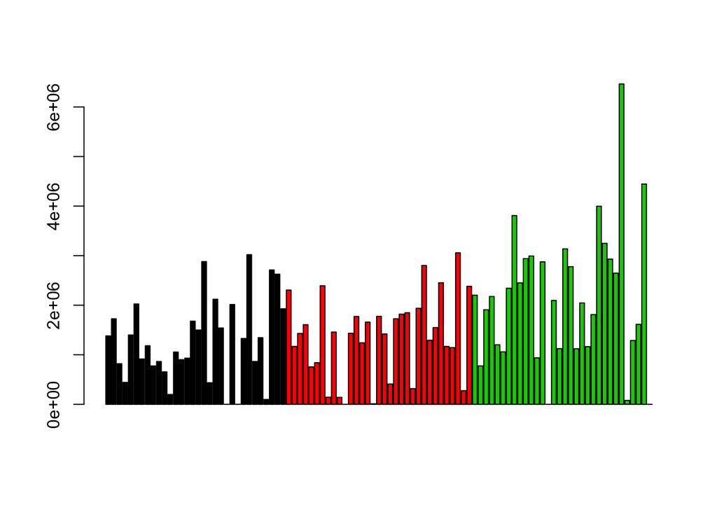

```r
barplot(reads$nreads, col=reads$Library)
```

### Definir colores

Los colores que R ocupa para colorear algo están definidos en `palette` y pueden cambiarse

```r
# Ver colores
palette()
```

```
## [1] "black"   "red"     "green3"  "blue"    "cyan"    "magenta" "yellow"
## [8] "gray"
```

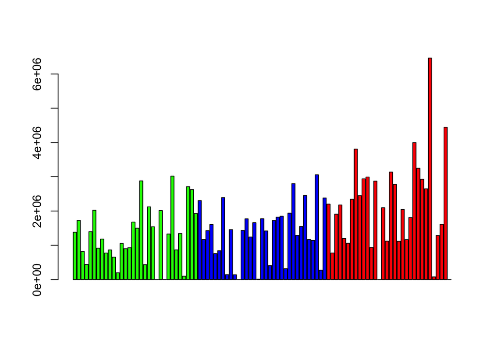

```r
# Cambiar colores
palette(c("green", "blue", "red"))

# volver a graficar
barplot(reads$nreads, col=reads$Library)
```

Además de manualmente, los colores se pueden definir via paletas predeterminadas:

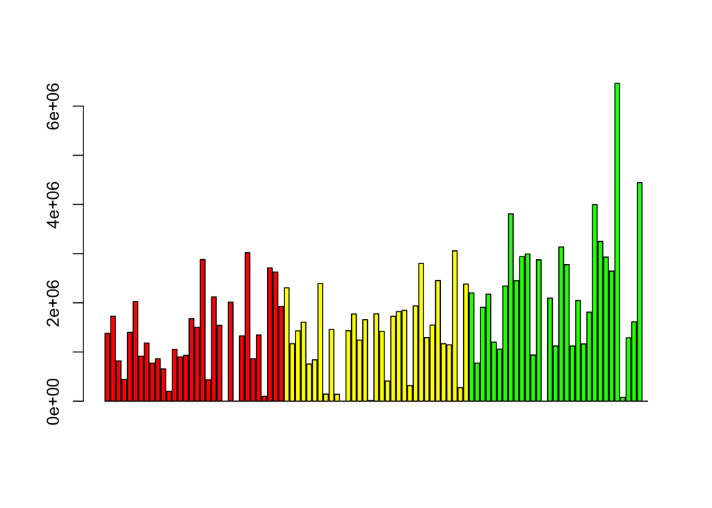

```r
# Cambiar palette a 6 colores del arcoiris
palette(rainbow(6))

# volver a graficar
barplot(reads$nreads, col=reads$Library)
```

Checa otras palettes parecidas a `rainbow` en [este link](http://www.r-bloggers.com/color-palettes-in-r/), y no te pierdas cómo nombrar muchos otros colores y utilizar otras paletas con más colores en la [R Color Reference Sheet](http://www.r-bloggers.com/r-color-reference-sheet/)

### Agregar una leyenda

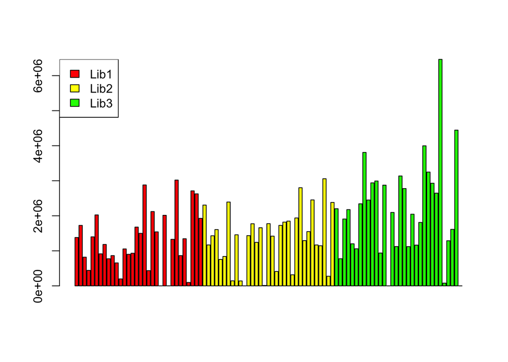

```r
# Graficar
barplot(reads$nreads, col=reads$Library)
# Agregar leyenda
legend(x="topleft", legend=levels(reads$Library), fill=palette()[1:3])
```

Nota que `legend` es una función por si misma (i.e. NO un argumento de `plot`) que requiere que antes de correrlo se haya corrido `plot`. Es decir una vez que creamos una gráfica podemos **agregar sobre de esta** una leyenda. Lo mismo puede hacerse con la función `title`.

### Boxplot

Ejemplo:

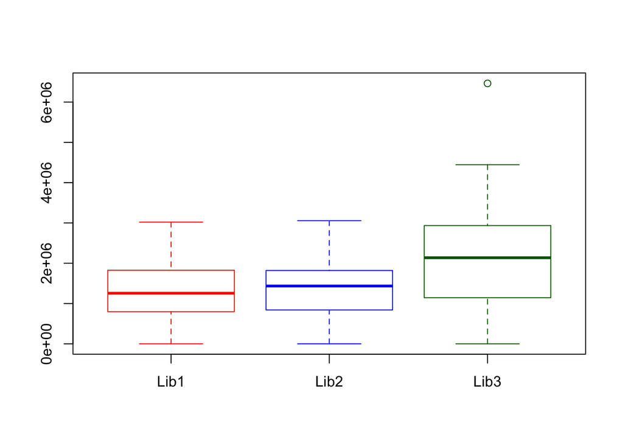

```r
boxplot(reads$nreads ~ reads$Library,
        border = c("red", "blue", "darkgreen"))
```

**Ejercicio** agrega un título a la gráfica de boxplot de los reads.

## Graficar árboles filogenéticos

La graficación de árboles filogenéticos se hace con el paquete `ape`, con el paquete `phytools` para funcionalidad extendida y con el paquete `ggtree`. Empezaremos por `ape`.

Bibliografía recomendada:

- [Phylogenetic trees in R, del blog Sensory Evolution](https://ecomorph.wordpress.com/2014/10/09/phylogenetic-trees-in-r-4/)
- [Blog de phytools](http://blog.phytools.org/)
- [Documentación de ggtree](https://www.bioconductor.org/packages/3.3/bioc/vignettes/ggtree/inst/doc/treeVisualization.html)

Los árboles filogenéticos pueden **construirse en R**, **simularse en R** o **leerse a R**.

Veamos un ejemplo con un árbol simulado:

```r
# Cargar librería
library(ape)
# Simular árbol
set.seed(1) # este comando es opcional, sirve para que todas "simulemos los mismos números" y podamos repetir de forma idéntica la simulación cada vez
tree <- rtree(n = 10, rooted=FALSE)

# ¿Qué tipo de objeto es?
class(tree)
```

```
## [1] "phylo"
```

```r
# ¿Qué contiene?
tree
```

```
##
## Phylogenetic tree with 10 tips and 8 internal nodes.
##
## Tip labels:
##  t10, t6, t9, t1, t2, t7, ...
##
## Unrooted; includes branch lengths.
```

```r
str(tree)
```

```
## List of 4
##  $ edge       : int [1:17, 1:2] 11 12 13 13 12 11 14 15 15 14 ...
##  $ tip.label  : chr [1:10] "t10" "t6" "t9" "t1" ...
##  $ edge.length: num [1:17] 0.718 0.992 0.38 0.777 0.935 ...
##  $ Nnode      : int 8
##  - attr(*, "class")= chr "phylo"
##  - attr(*, "order")= chr "cladewise"
```

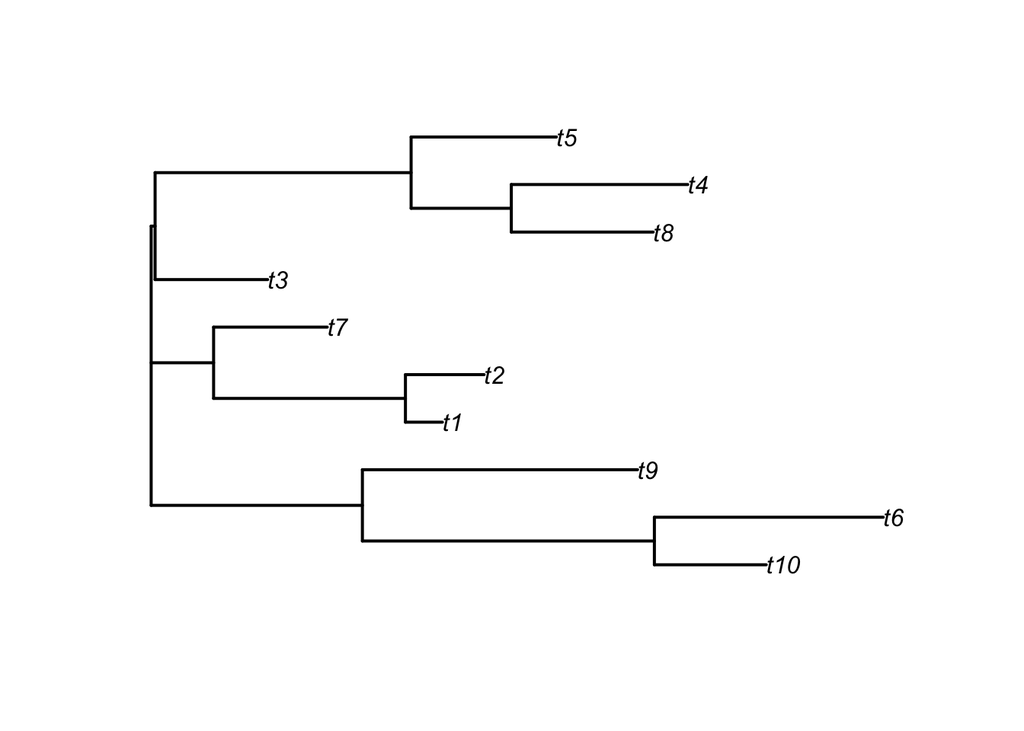

```r
# Graficar el árbol
plot.phylo(tree, edge.width=2)
```

Podemos modificar este árbol de manera similar a cómo lo hicimos en las gráficas anteriores.

## Cambiar el tipo de árbol

**Ejercicio** Revisa la ayuda de `plot.phylo` y utiliza un argumento de dicha función para graficar el árbol simulado pero que se vea como un abanico y luego como un cladograma (así):

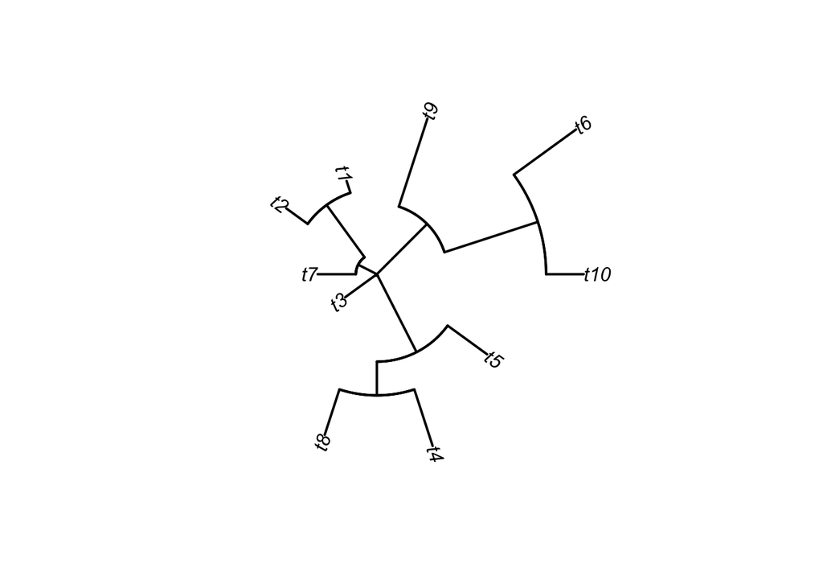

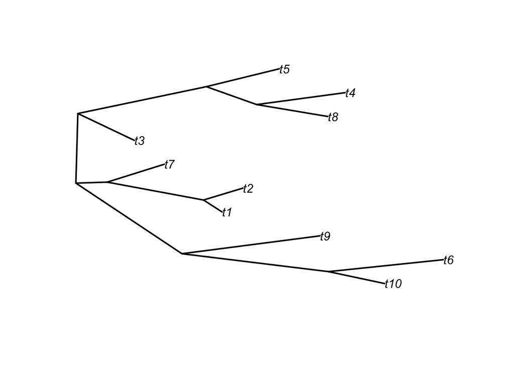

## Enraizar el árbol

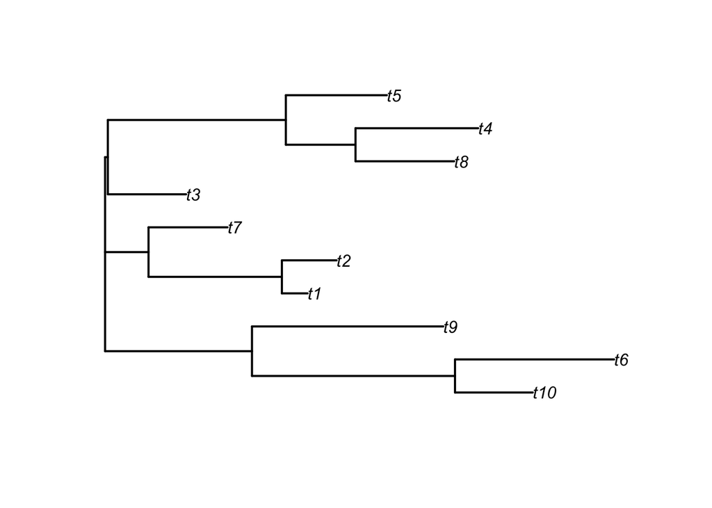

```r
# plot árbol sin enraizar
plot.phylo(tree, edge.width=2)
```

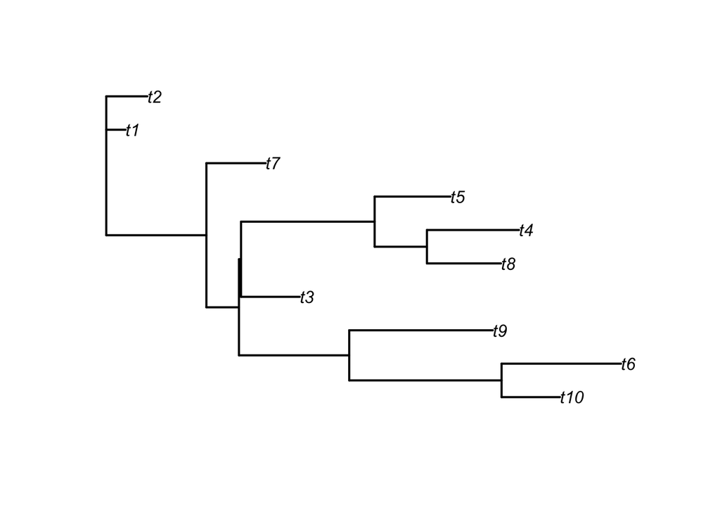

```r
# especificar output para enraizar:
tree<-root(tree, outgroup="t2")

# plot árbol enraizado
plot.phylo(tree, edge.width=2)
```

## Chulear el árbol

**Ejercicio:** Sigue los ejemplos de [Phylogenetic trees in R, del blog Sensory Evolution](https://ecomorph.wordpress.com/2014/10/09/phylogenetic-trees-in-r-4/) para realizar los siguientes cambios al árbol anterior:

- Cambia el nombre de las puntas de “t1”, “t2” etc a “especie 1”, “especie 2”, etc y asegúrate de graficar estos nombres en las puntas de tu árbol
- Agrega un círculo en los nombres de las puntas. El clado de las puntas t9, t6 y t 10 debe tener círculos rosas, la punta t2 gris y el resto verdes.
- Incremente al grosor de la línea
- Cambia el color de la línea a verde oscuro

## Leer un árbol en R y graficarlo

Podemos leer árboles en formato newick o nexus a R con la función `read.tree` de `ape`:

```r
# cargar archivo
maiz.tree<-read.tree("../Practicas/Uni7/data/maiztree")

# checar contenido
maiz.tree
```

```
##
## Phylogenetic tree with 165 tips and 163 internal nodes.
##
## Tip labels:
##  maiz_192, maiz_187, maiz_65, maiz_57, maiz_68, maiz_101, ...
##
## Unrooted; includes branch lengths.
```

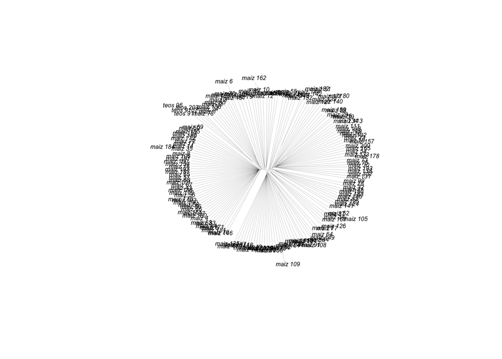

```r
# graficar
plot(maiz.tree, type="unrooted", edge.width=0.1, cex=0.5)
```

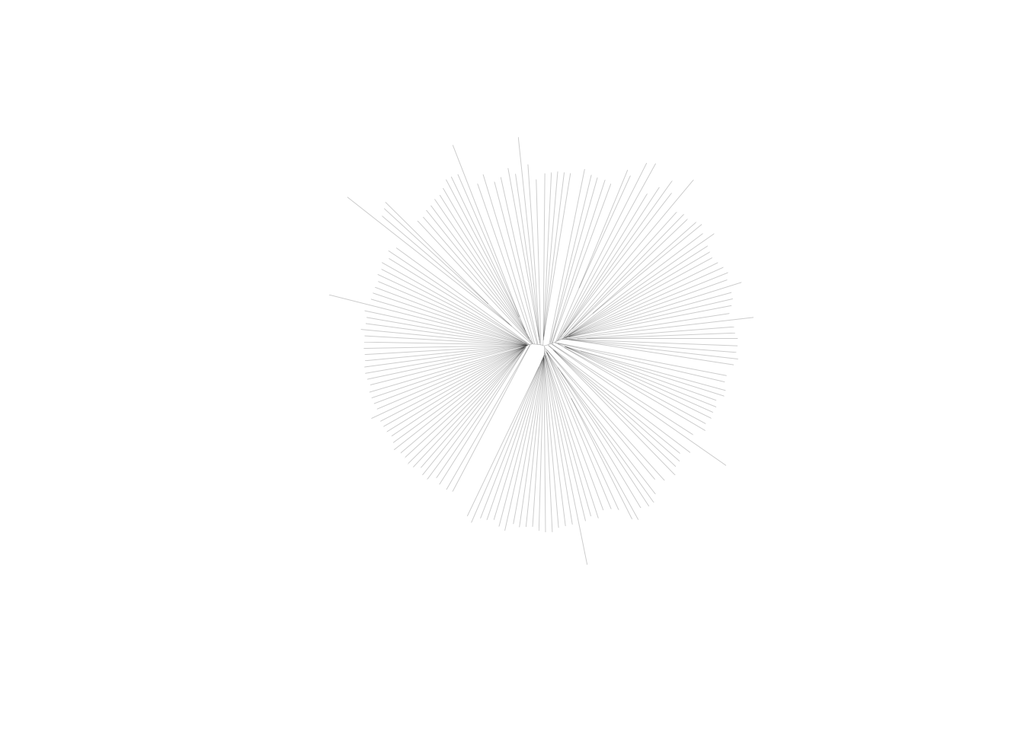

```r
# graficar sin nombres de muestras
plot(maiz.tree, type="unrooted", edge.width=0.1, show.tip=FALSE)
```

En los ejercicios siguientes haremos que ese árbol muestre más información.